# Statistical inference with the GSS data

Raymond Ngiam Heng Aik

29 June 2016

## Setup

### Load packages

```r
library(ggplot2)
library(dplyr)
library(statsr)
```

### Load data

Make sure your data and R Markdown files are in the same directory. When loaded your data file will be called `gss`. Delete this note when before you submit your work.

```r
load("gss.Rdata")
```

## Part 1: Data

**How the observations in the sample are collected:**

Each survey from 1972 to 2004 was an independently drawn sample of English-speaking persons 18 years of age or over, living in non-institutional arrangements within the United States.Starting in 2006 Spanish-speakers were added to the target population [1].

Block quota sampling was used in surveys from 1972 to 1976. Full probability sampling was employed fully from 1977 onwards up to 2014 [1].

**Implications of this data collection method on the scope of inference (generalizability):**

Since the data collection involves random sampling, the sample can be considered representative of the population. Hence findings from this observational study can be generalized to the entire population.

**Implications of this data collection method on the scope of inference (causality):**

Since this is an observational study, not an experiment where subjects are randomly assigned for specific treatments, hence, the findings on relationship among different factors only establish association but do not imply causality.

## Part 2: Research question

**Research quesion: According “The World Factbook” by CIA, the estimated mother’s average age at first birth in 2011 for the United States is 25.6 [2]. Does the GSS survey provide convincing evidence that the mother’s average age at first birth of the population in 2012 is equal to 25.6?**

This research question is of interest because mother’s average age at first birth is an useful indicator for gauging the success of family planning programs aiming to reduce maternal mortality, increase contraceptive use - particularly among married and unmarried adolescents, delay age at first marriage, and improve the health of newborns [2].

## Part 3: Exploratory data analysis

The dataset is filtered for female respondents in year 2012. Entries with not applicable (NA) cell for the “agekdbrn” (Age When First Kid Born) column are removed.

```r
q3data <- gss %>%
  filter(year==2012,sex=="Female",!(is.na(agekdbrn)))
N3 <- dim(q3data)[1]
N3
```

```
## [1] 846
```

Total sample count obtained is 846.

Histogram for Female Age when First Kid Born in 2012:

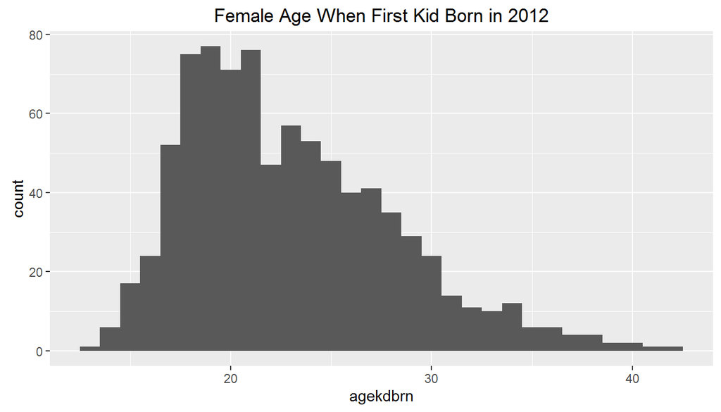

```r
ggplot(data = q3data, aes(x = agekdbrn)) +
  geom_histogram(binwidth=1) +
  labs(title = "Female Age When First Kid Born in 2012")
```

Boxplot for Female Age when First Kid Born in 2012:

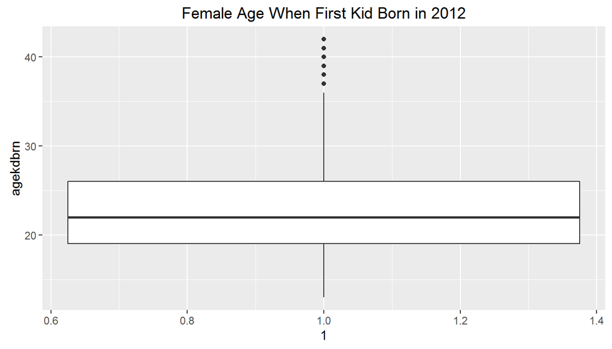

```r
ggplot(data = q3data, aes(x = 1, y = agekdbrn)) +
  geom_boxplot() +
  labs(title = "Female Age When First Kid Born in 2012")
```

Summary statistics for Female Age when First Kid Born in 2012:

```r
q3data %>%
  summarize(mean_agekdbrn = mean(agekdbrn), sd_agekdbrn = sd(agekdbrn),median_agekdbrn = median(agekdbrn), IQR_agekdbrn = IQR(agekdbrn), N = n())
```

```
##   mean_agekdbrn sd_agekdbrn median_agekdbrn IQR_agekdbrn   N
## 1      22.98463    5.188836              22            7 846
```

Interpretation: The distribution for Female Age When First Kid Born in the sample polulation is skewed to the right, with mean equal 22.98 and standard deviation equal 5.19.

## Part 4: Inference

Point estimate
$$\bar{x} = 22.98$$
$$s = 5.19$$
$$n = 846$$

Hypotheses
$$H_{0} : \mu = 25.6$$
$$H_{A} : \mu \neq 25.6$$

Check conditions

1. Independence:
   - 846 < 10 % of English and Spanish-speaking mothers 18 years of age or over, living in non-institutional arrangements within the United States.
   - Random sample

   One mother’s age at first birth in the sample is independent of another.
2. Sample size / skew:
   - From explanatory data analysis, we observed the sample distribution is skewed to the right. Due to this violation in normality assumptions, inference on mean from this sample based on normal distribution is not valid since the sampling distribution will not be normal. However, by using t-distribution and with considerably large amount of samples, i.e 846, the normal approximation should be robust to skewness in the sample distribution.

   Nearly normal sampling distribution under t-distribution.

Inference method to be used

Theoretical based inference is used since the sampling distribution is nearly normal under t-distribution. t-distribution is used as the sampling distribution, and the test statistic, t score, is computed based on null hypothesis, $H_{0}$. If the corresponding p-value to the t score is lesser than the significant level, $\alpha$, $H_{0}$ is rejected. And we can conclude that the data provide convincing evidence for $H_{A}$.

Inference

Hypothesis testing:

```r
inference(y = agekdbrn, data = q3data, statistic = "mean", type = "ht",null = 25.6, alternative = "twosided", method = "theoretical")
```

```
## Single numerical variable
## n = 846, y-bar = 22.9846, s = 5.1888
## H0: mu = 25.6
## HA: mu != 25.6
## t = -14.6605, df = 845
## p_value = < 0.0001
```

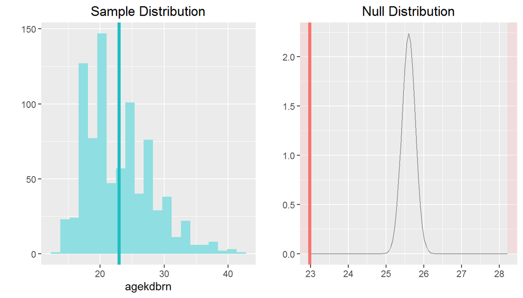

Confidence interval:

```r
inference(y = agekdbrn, data = q3data, statistic = "mean", type = "ci", method = "theoretical")
```

```
## Single numerical variable
## n = 846, y-bar = 22.9846, s = 5.1888
## 95% CI: (22.6345 , 23.3348)
```

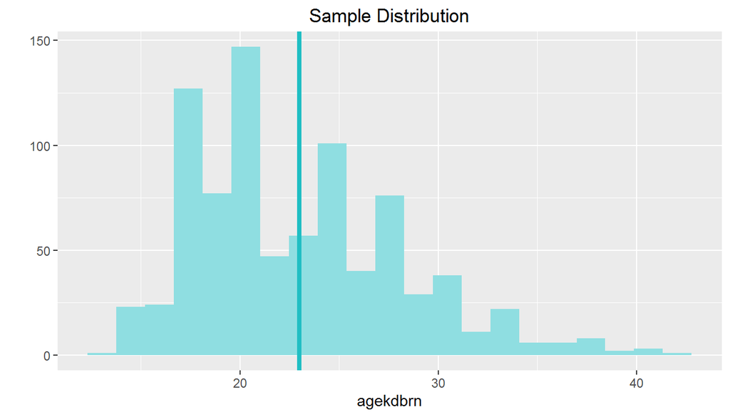

Interpretation

Since the p-value obtained is < 0.0001, which is lesser than the standard significant level of 5%, we reject the $H_{0}$, and conclude that the GSS survey provide convincing evidence that the mother’s average age at first birth of the population in 2012 is not equal to 25.6.

We can further verify that the result from the hypothesis testing with the confidence interval computed. Since we rejected $H_{0}$ which states $\mu$=25.6 at 5% significant level, the 95% confidence interval of the population mean which is (22.6345 , 23.3348) does not contain the value 25.6.

## References

[1] *General Social Survey 1972-2014 Cumulative Codebook*, National Opinion Research Center, University of Chicago. Retrieved 29 June, 2016. [Link](http://gss.norc.org/documents/codebook/GSS_Codebook.pdf)

[2] *The World Factbook - Mother’s Mean Age at First Birth*, Central Intelligence Agency. Retrieved 29 June, 2016. [Link](https://www.cia.gov/library/publications/the-world-factbook/fields/2256.html)